# ADL - Recovery time - Vertical speed

Philippine Chambault

2023-01-12

**Background**: Investigation of vertical speed and recovery times in relation to ADL (from literature) in harbour porpoise, and potential relationship with dive depth and duration. Dive threshold = 5 m. Analysis on high resolution dataset (n=5).

ADL estimated from literature:

- Noren et al 2014: 3.3-6.5 for a 37 kg juvenile; 3.5-6.9 for a 50 kg adult
- Reed et al. 2000: 5.4 min for a 28 kg porpoise
- Otani et al. 2001: 4.5 min for 37 and 48 kg porpoises
- McDonald et al 2021: 5 min for a 67 kg adult, 4.2 min for a 44 kg porpoise, 3 min for a 30 kg porpoise, 3.6 min for a 28 kg porpoise and 2.2 min for a 26 kg porpoise.

Oxygen stores estimated:

- Otani et al. 2001: in porpoises: 37.2 ml O2 per kg
- Williams : in dolphins: 33 ml O2 per kg

# 1 Maxdep vs duration

```
##
##  Pearson's product-moment correlation
##
## data:  clust$dur and clust$maxdep
## t = 797.04, df = 250141, p-value < 2.2e-16
## alternative hypothesis: true correlation is not equal to 0
## 95 percent confidence interval:
##  0.8459356 0.8481499
## sample estimates:
##       cor
## 0.8470464
```

```
## [1] 3.063478
```

## 1.1 Per ID

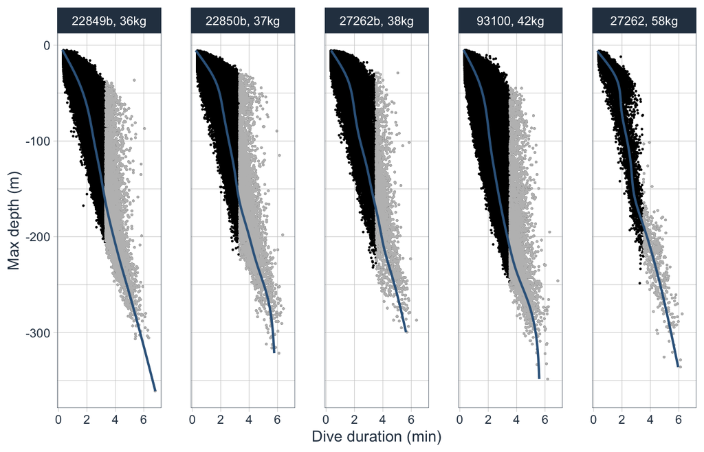

Figure 1.1: Relationship between max depth and dive duration per individual. Grey dots refer to dives beyond the estimated ADL per age class from Noren et al 2014.

## 1.2 All

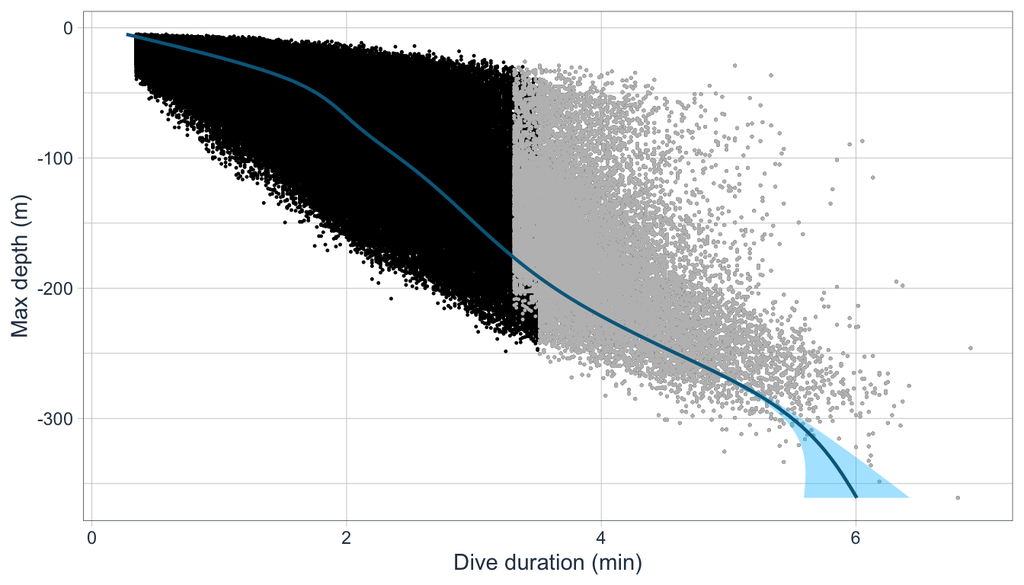

Figure 1.2: Relationship between max depth and dive duration for the 5 porpoises. Grey dots refer to dives beyond the estimated ADL per age class from Noren et al 2014.

## 1.3 Dive proportions

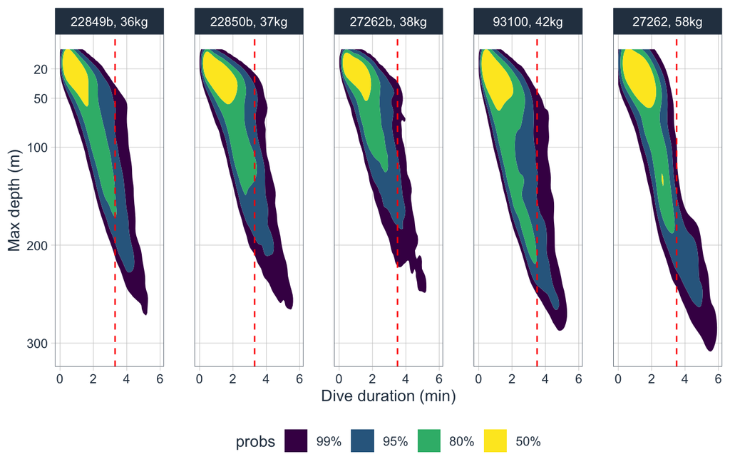

Figure 1.3: Density plots showing the porportions of dives according to depth and duration. Red dotted lines refer to the calculated ADL per age class derived from Noren et al 2014.

Despite in lower proportions, a signifcant number of dives were performed outside the estimated ADL from Noren et al 2014.

# 2 Recovery time

## 2.1 Dive proportions

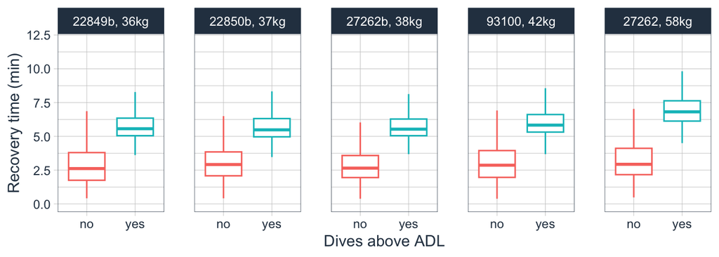

Figure 2.1: Boxplots showing the recovery times according to the cADL from Noren et al 2014 (e.g. no: dives below cADL vs. yes: dives above cADL).

Dives above cADL show longer recovery times, and bigger porpoises (#93100 and #27262) exhibit longer recovery times for dives above cADL.

## 2.2 vs. dive duration

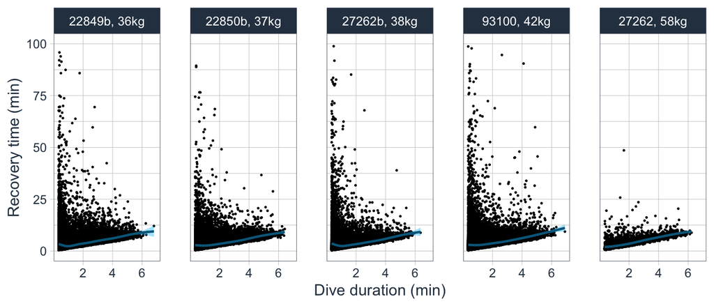

Figure 2.2: Relationship between recovery time and dive duration.

## 2.3 vs. dive duration updated

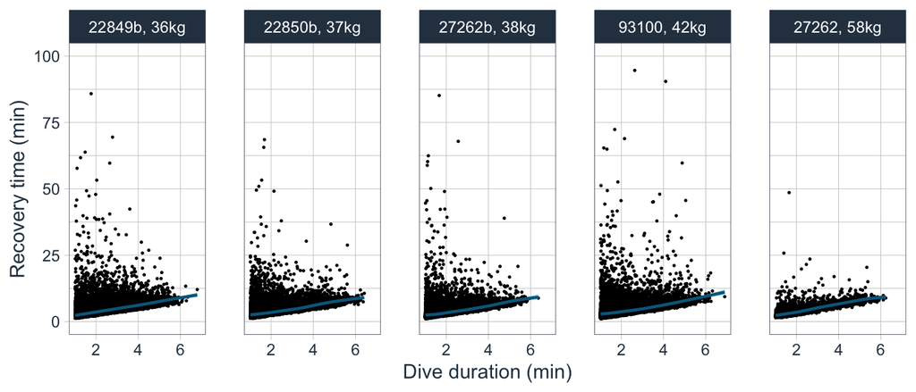

# 3 Relationship with body mass

## 3.1 Daily mean dive duration

```
##
##  Pearson's product-moment correlation
##
## data:  sum2$meandur and sum2$weight
## t = 1.1908, df = 3, p-value = 0.3194
## alternative hypothesis: true correlation is not equal to 0
## 95 percent confidence interval:
##  -0.6312677  0.9659725
## sample estimates:
##       cor
## 0.5665199
```

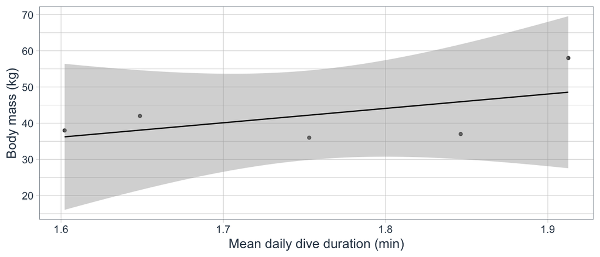

Figure 3.1: Relationship between body mass and daily mean dive duration.

## 3.2 Mean dive duration

```
##
##  Pearson's product-moment correlation
##
## data:  sum2$meandur and sum2$weight
## t = 1.8386, df = 3, p-value = 0.1633
## alternative hypothesis: true correlation is not equal to 0
## 95 percent confidence interval:
##  -0.4314783  0.9804904
## sample estimates:
##       cor
## 0.7278745
```

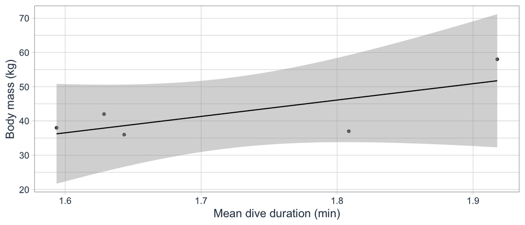

Figure 3.2: Relationship between body mass and mean dive duration.

Very small sample size but increasing relationship.

# 4 In summary

Based on ADL calculated from Noren et al 2014 and McDonald et al 2021, a significant proportion of dives were longer than ADL for the 5 individuals. Without the metabolic rate and oxygen consumption, not easy to estimate when only body mass available. ADLs from Reed et al 2000 and Otani et al 2001 seem more realistic but quite old references that might not be up to date.